# Risk Factor Analysis

## Outcome Variable

**Outcome Variable:** ever_stunted

## Predictor Variables

**Intervention Variable:** feducyrs

**Adjustment Set:**

- arm
- W_mage
- meducyrs
- hhwealth_quart
- W_mhtcm
- W_mwtkg
- W_mbmi
- W_gagebrth
- W_birthwt
- W_birthlen
- single
- delta_W_mage
- delta_meducyrs
- delta_hhwealth_quart
- delta_W_mhtcm
- delta_W_mwtkg
- delta_W_mbmi
- delta_W_gagebrth
- delta_W_birthwt
- delta_W_birthlen
- delta_single

## Stratifying Variables

The analysis was stratified on these variable(s):

- agecat
- studyid
- country

## Data Summary

| agecat | studyid | country | feducyrs | ever_stunted | n_cell | n |
| --- | --- | --- | --- | --- | --- | --- |
| 0-24 months | COHORTS | GUATEMALA | High | 0 | 55 | 1250 |
| 0-24 months | COHORTS | GUATEMALA | High | 1 | 179 | 1250 |
| 0-24 months | COHORTS | GUATEMALA | Low | 0 | 122 | 1250 |
| 0-24 months | COHORTS | GUATEMALA | Low | 1 | 445 | 1250 |
| 0-24 months | COHORTS | GUATEMALA | Medium | 0 | 114 | 1250 |
| 0-24 months | COHORTS | GUATEMALA | Medium | 1 | 335 | 1250 |
| 0-24 months | COHORTS | INDIA | High | 0 | 404 | 1447 |
| 0-24 months | COHORTS | INDIA | High | 1 | 163 | 1447 |
| 0-24 months | COHORTS | INDIA | Low | 0 | 240 | 1447 |
| 0-24 months | COHORTS | INDIA | Low | 1 | 232 | 1447 |
| 0-24 months | COHORTS | INDIA | Medium | 0 | 256 | 1447 |
| 0-24 months | COHORTS | INDIA | Medium | 1 | 152 | 1447 |
| 0-24 months | COHORTS | PHILIPPINES | High | 0 | 466 | 2880 |
| 0-24 months | COHORTS | PHILIPPINES | High | 1 | 565 | 2880 |
| 0-24 months | COHORTS | PHILIPPINES | Low | 0 | 160 | 2880 |
| 0-24 months | COHORTS | PHILIPPINES | Low | 1 | 668 | 2880 |
| 0-24 months | COHORTS | PHILIPPINES | Medium | 0 | 267 | 2880 |
| 0-24 months | COHORTS | PHILIPPINES | Medium | 1 | 754 | 2880 |
| 0-24 months | GMS-Nepal | NEPAL | High | 0 | 79 | 696 |
| 0-24 months | GMS-Nepal | NEPAL | High | 1 | 94 | 696 |
| 0-24 months | GMS-Nepal | NEPAL | Low | 0 | 92 | 696 |
| 0-24 months | GMS-Nepal | NEPAL | Low | 1 | 204 | 696 |
| 0-24 months | GMS-Nepal | NEPAL | Medium | 0 | 79 | 696 |
| 0-24 months | GMS-Nepal | NEPAL | Medium | 1 | 148 | 696 |
| 0-24 months | JiVitA-3 | BANGLADESH | High | 0 | 3975 | 26233 |
| 0-24 months | JiVitA-3 | BANGLADESH | High | 1 | 2529 | 26233 |
| 0-24 months | JiVitA-3 | BANGLADESH | Low | 0 | 4982 | 26233 |
| 0-24 months | JiVitA-3 | BANGLADESH | Low | 1 | 5803 | 26233 |
| 0-24 months | JiVitA-3 | BANGLADESH | Medium | 0 | 4339 | 26233 |
| 0-24 months | JiVitA-3 | BANGLADESH | Medium | 1 | 4605 | 26233 |

[output cut: 330 more lines]

The following strata were considered:

- agecat: 0-24 months, studyid: COHORTS, country: GUATEMALA
- agecat: 0-24 months, studyid: COHORTS, country: INDIA
- agecat: 0-24 months, studyid: COHORTS, country: PHILIPPINES
- agecat: 0-24 months, studyid: GMS-Nepal, country: NEPAL
- agecat: 0-24 months, studyid: JiVitA-3, country: BANGLADESH
- agecat: 0-24 months, studyid: JiVitA-4, country: BANGLADESH
- agecat: 0-24 months, studyid: LCNI-5, country: MALAWI
- agecat: 0-24 months, studyid: MAL-ED, country: BANGLADESH
- agecat: 0-24 months, studyid: MAL-ED, country: INDIA
- agecat: 0-24 months, studyid: MAL-ED, country: NEPAL
- agecat: 0-24 months, studyid: MAL-ED, country: PERU
- agecat: 0-24 months, studyid: MAL-ED, country: SOUTH AFRICA
- agecat: 0-24 months, studyid: MAL-ED, country: TANZANIA, UNITED REPUBLIC OF
- agecat: 0-24 months, studyid: NIH-Crypto, country: BANGLADESH
- agecat: 0-24 months, studyid: PROBIT, country: BELARUS
- agecat: 0-24 months, studyid: PROVIDE, country: BANGLADESH
- agecat: 0-24 months, studyid: SAS-CompFeed, country: INDIA
- agecat: 0-24 months, studyid: SAS-FoodSuppl, country: INDIA
- agecat: 0-24 months, studyid: TanzaniaChild2, country: TANZANIA, UNITED REPUBLIC OF
- agecat: 0-24 months, studyid: ZVITAMBO, country: ZIMBABWE
- agecat: 0-6 months, studyid: COHORTS, country: GUATEMALA
- agecat: 0-6 months, studyid: COHORTS, country: INDIA
- agecat: 0-6 months, studyid: COHORTS, country: PHILIPPINES
- agecat: 0-6 months, studyid: GMS-Nepal, country: NEPAL
- agecat: 0-6 months, studyid: JiVitA-3, country: BANGLADESH
- agecat: 0-6 months, studyid: JiVitA-4, country: BANGLADESH
- agecat: 0-6 months, studyid: LCNI-5, country: MALAWI
- agecat: 0-6 months, studyid: MAL-ED, country: BANGLADESH
- agecat: 0-6 months, studyid: MAL-ED, country: INDIA
- agecat: 0-6 months, studyid: MAL-ED, country: NEPAL
- agecat: 0-6 months, studyid: MAL-ED, country: PERU
- agecat: 0-6 months, studyid: MAL-ED, country: SOUTH AFRICA
- agecat: 0-6 months, studyid: MAL-ED, country: TANZANIA, UNITED REPUBLIC OF
- agecat: 0-6 months, studyid: NIH-Crypto, country: BANGLADESH
- agecat: 0-6 months, studyid: PROBIT, country: BELARUS
- agecat: 0-6 months, studyid: PROVIDE, country: BANGLADESH
- agecat: 0-6 months, studyid: SAS-CompFeed, country: INDIA
- agecat: 0-6 months, studyid: SAS-FoodSuppl, country: INDIA
- agecat: 0-6 months, studyid: TanzaniaChild2, country: TANZANIA, UNITED REPUBLIC OF
- agecat: 0-6 months, studyid: ZVITAMBO, country: ZIMBABWE
- agecat: 6-24 months, studyid: COHORTS, country: GUATEMALA
- agecat: 6-24 months, studyid: COHORTS, country: INDIA
- agecat: 6-24 months, studyid: COHORTS, country: PHILIPPINES
- agecat: 6-24 months, studyid: GMS-Nepal, country: NEPAL
- agecat: 6-24 months, studyid: JiVitA-3, country: BANGLADESH
- agecat: 6-24 months, studyid: JiVitA-4, country: BANGLADESH
- agecat: 6-24 months, studyid: LCNI-5, country: MALAWI
- agecat: 6-24 months, studyid: MAL-ED, country: BANGLADESH
- agecat: 6-24 months, studyid: MAL-ED, country: INDIA
- agecat: 6-24 months, studyid: MAL-ED, country: NEPAL
- agecat: 6-24 months, studyid: MAL-ED, country: PERU
- agecat: 6-24 months, studyid: MAL-ED, country: SOUTH AFRICA
- agecat: 6-24 months, studyid: MAL-ED, country: TANZANIA, UNITED REPUBLIC OF
- agecat: 6-24 months, studyid: NIH-Crypto, country: BANGLADESH
- agecat: 6-24 months, studyid: PROBIT, country: BELARUS
- agecat: 6-24 months, studyid: PROVIDE, country: BANGLADESH
- agecat: 6-24 months, studyid: SAS-CompFeed, country: INDIA
- agecat: 6-24 months, studyid: SAS-FoodSuppl, country: INDIA
- agecat: 6-24 months, studyid: TanzaniaChild2, country: TANZANIA, UNITED REPUBLIC OF
- agecat: 6-24 months, studyid: ZVITAMBO, country: ZIMBABWE

### Dropped Strata

Some strata were dropped due to rare outcomes:

- agecat: 0-24 months, studyid: MAL-ED, country: TANZANIA, UNITED REPUBLIC OF
- agecat: 0-6 months, studyid: MAL-ED, country: NEPAL
- agecat: 6-24 months, studyid: MAL-ED, country: NEPAL
- agecat: 6-24 months, studyid: MAL-ED, country: TANZANIA, UNITED REPUBLIC OF

## Methods Detail

We're interested in the causal parameters $E[Y_a]$ for all values of $a \in \mathcal{A}$. These parameters represent the mean outcome if, possibly contrary to fact, we intervened to set all units to have $A=a$. Under the randomization and positivity assumptions, these are identified by the statistical parameters $\psi_a=E_W[E_{Y|A,W}(Y|A=a,W)]$. In addition, we're interested in the mean of $Y$, $E[Y]$ under no intervention (the observed mean). We will estimate these parameters by using SuperLearner to fit the relevant likelihood factors -- $E_{Y|A,W}(Y|A=a,W)$ and $p(A=a|W)$, and then updating our likelihood fit using a joint TMLE.

For unadjusted analyses ($W=\{\}$), initial likelihoods were estimated using Lrnr_glm to estimate the simple $E(Y|A)$ and Lrnr_mean to estimate $p(A)$. For adjusted analyses, a small library containing Lrnr_glmnet, Lrnr_xgboost, and Lrnr_mean was used.

Having estimated these parameters, we will then use the delta method to estimate relative risks and attributable risks relative to a prespecified baseline level of $A$.

# Results Detail

## Results Plots

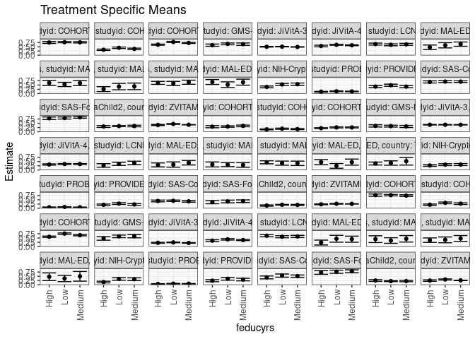

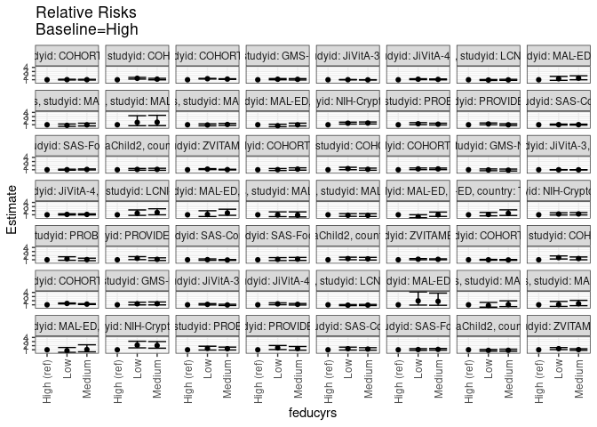

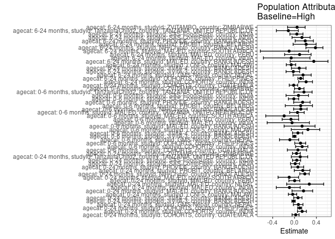

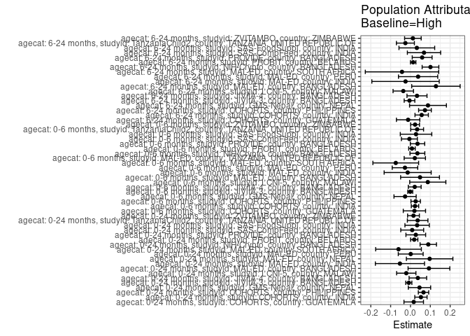

## Results Table

### Parameter: TSM

| agecat | studyid | country | intervention_level | baseline_level | estimate | ci_lower | ci_upper |
| --- | --- | --- | --- | --- | --- | --- | --- |
| 0-24 months | COHORTS | GUATEMALA | High | NA | 0.7508058 | 0.6958539 | 0.8057578 |
| 0-24 months | COHORTS | GUATEMALA | Low | NA | 0.7696583 | 0.7354510 | 0.8038656 |
| 0-24 months | COHORTS | GUATEMALA | Medium | NA | 0.7627674 | 0.7241928 | 0.8013419 |
| 0-24 months | COHORTS | INDIA | High | NA | 0.3253438 | 0.2867167 | 0.3639708 |
| 0-24 months | COHORTS | INDIA | Low | NA | 0.4395413 | 0.3964168 | 0.4826659 |
| 0-24 months | COHORTS | INDIA | Medium | NA | 0.3738097 | 0.3290822 | 0.4185371 |
| 0-24 months | COHORTS | PHILIPPINES | High | NA | 0.6242363 | 0.5924337 | 0.6560389 |
| 0-24 months | COHORTS | PHILIPPINES | Low | NA | 0.7815645 | 0.7494312 | 0.8136978 |
| 0-24 months | COHORTS | PHILIPPINES | Medium | NA | 0.7261267 | 0.6966277 | 0.7556258 |
| 0-24 months | GMS-Nepal | NEPAL | High | NA | 0.5953654 | 0.5299276 | 0.6608031 |
| 0-24 months | GMS-Nepal | NEPAL | Low | NA | 0.6704684 | 0.6173559 | 0.7235808 |
| 0-24 months | GMS-Nepal | NEPAL | Medium | NA | 0.6539160 | 0.5837707 | 0.7240614 |
| 0-24 months | JiVitA-3 | BANGLADESH | High | NA | 0.5015500 | 0.4845002 | 0.5185997 |
| 0-24 months | JiVitA-3 | BANGLADESH | Low | NA | 0.5082214 | 0.4953341 | 0.5211086 |
| 0-24 months | JiVitA-3 | BANGLADESH | Medium | NA | 0.4909308 | 0.4793449 | 0.5025168 |
| 0-24 months | JiVitA-4 | BANGLADESH | High | NA | 0.5448231 | 0.4965519 | 0.5930943 |
| 0-24 months | JiVitA-4 | BANGLADESH | Low | NA | 0.6166948 | 0.5877022 | 0.6456875 |
| 0-24 months | JiVitA-4 | BANGLADESH | Medium | NA | 0.5892523 | 0.5632303 | 0.6152744 |
| 0-24 months | LCNI-5 | MALAWI | High | NA | 0.6583273 | 0.5999184 | 0.7167362 |
| 0-24 months | LCNI-5 | MALAWI | Low | NA | 0.6167942 | 0.5615629 | 0.6720256 |
| 0-24 months | LCNI-5 | MALAWI | Medium | NA | 0.6420475 | 0.5852937 | 0.6988013 |
| 0-24 months | MAL-ED | BANGLADESH | High | NA | 0.4706741 | 0.3380561 | 0.6032921 |
| 0-24 months | MAL-ED | BANGLADESH | Low | NA | 0.5869286 | 0.4330473 | 0.7408098 |
| 0-24 months | MAL-ED | BANGLADESH | Medium | NA | 0.6563840 | 0.5295661 | 0.7832019 |
| 0-24 months | MAL-ED | INDIA | High | NA | 0.6245570 | 0.4772783 | 0.7718357 |
| 0-24 months | MAL-ED | INDIA | Low | NA | 0.5342328 | 0.4095186 | 0.6589470 |
| 0-24 months | MAL-ED | INDIA | Medium | NA | 0.6150168 | 0.4679323 | 0.7621013 |
| 0-24 months | MAL-ED | NEPAL | High | NA | 0.2605476 | 0.1180680 | 0.4030273 |
| 0-24 months | MAL-ED | NEPAL | Low | NA | 0.4084118 | 0.2187987 | 0.5980249 |
| 0-24 months | MAL-ED | NEPAL | Medium | NA | 0.4213489 | 0.2262594 | 0.6164384 |

[output cut: 138 more lines]

### Parameter: E(Y)

| agecat | studyid | country | intervention_level | baseline_level | estimate | ci_lower | ci_upper |
| --- | --- | --- | --- | --- | --- | --- | --- |
| 0-24 months | COHORTS | GUATEMALA | NA | NA | 0.7672000 | 0.7437624 | 0.7906376 |
| 0-24 months | COHORTS | INDIA | NA | NA | 0.3780235 | 0.3530310 | 0.4030160 |
| 0-24 months | COHORTS | PHILIPPINES | NA | NA | 0.6899306 | 0.6730355 | 0.7068256 |
| 0-24 months | GMS-Nepal | NEPAL | NA | NA | 0.6408046 | 0.6051362 | 0.6764730 |
| 0-24 months | JiVitA-3 | BANGLADESH | NA | NA | 0.4931575 | 0.4852626 | 0.5010523 |
| 0-24 months | JiVitA-4 | BANGLADESH | NA | NA | 0.5820697 | 0.5655159 | 0.5986236 |
| 0-24 months | LCNI-5 | MALAWI | NA | NA | 0.6371464 | 0.6040748 | 0.6702180 |
| 0-24 months | MAL-ED | BANGLADESH | NA | NA | 0.5637584 | 0.4838620 | 0.6436548 |
| 0-24 months | MAL-ED | INDIA | NA | NA | 0.5714286 | 0.4911565 | 0.6517006 |
| 0-24 months | MAL-ED | NEPAL | NA | NA | 0.3571429 | 0.2617885 | 0.4524972 |
| 0-24 months | MAL-ED | PERU | NA | NA | 0.6280000 | 0.5679657 | 0.6880343 |
| 0-24 months | MAL-ED | SOUTH AFRICA | NA | NA | 0.6181818 | 0.5269763 | 0.7093874 |
| 0-24 months | NIH-Crypto | BANGLADESH | NA | NA | 0.4775726 | 0.4419904 | 0.5131548 |
| 0-24 months | PROBIT | BELARUS | NA | NA | 0.1247395 | 0.1090645 | 0.1404144 |
| 0-24 months | PROVIDE | BANGLADESH | NA | NA | 0.4357143 | 0.3989556 | 0.4724730 |
| 0-24 months | SAS-CompFeed | INDIA | NA | NA | 0.6908497 | 0.6505448 | 0.7311545 |
| 0-24 months | SAS-FoodSuppl | INDIA | NA | NA | 0.8277512 | 0.7915095 | 0.8639929 |
| 0-24 months | TanzaniaChild2 | TANZANIA, UNITED REPUBLIC OF | NA | NA | 0.3466219 | 0.3275107 | 0.3657331 |
| 0-24 months | ZVITAMBO | ZIMBABWE | NA | NA | 0.4136118 | 0.4053631 | 0.4218605 |
| 0-6 months | COHORTS | GUATEMALA | NA | NA | 0.3196078 | 0.2909760 | 0.3482397 |
| 0-6 months | COHORTS | INDIA | NA | NA | 0.1639690 | 0.1447117 | 0.1832264 |
| 0-6 months | COHORTS | PHILIPPINES | NA | NA | 0.2381944 | 0.2226342 | 0.2537546 |
| 0-6 months | GMS-Nepal | NEPAL | NA | NA | 0.3189655 | 0.2843148 | 0.3536162 |
| 0-6 months | JiVitA-3 | BANGLADESH | NA | NA | 0.4111421 | 0.4035964 | 0.4186878 |
| 0-6 months | JiVitA-4 | BANGLADESH | NA | NA | 0.3469880 | 0.3313196 | 0.3626563 |
| 0-6 months | LCNI-5 | MALAWI | NA | NA | 0.3558052 | 0.2982716 | 0.4133389 |
| 0-6 months | MAL-ED | BANGLADESH | NA | NA | 0.3489933 | 0.2722008 | 0.4257857 |
| 0-6 months | MAL-ED | INDIA | NA | NA | 0.3129252 | 0.2377120 | 0.3881383 |
| 0-6 months | MAL-ED | PERU | NA | NA | 0.4280000 | 0.3665434 | 0.4894566 |
| 0-6 months | MAL-ED | SOUTH AFRICA | NA | NA | 0.3909091 | 0.2993052 | 0.4825130 |
| 0-6 months | MAL-ED | TANZANIA, UNITED REPUBLIC OF | NA | NA | 0.4056604 | 0.3394074 | 0.4719134 |
| 0-6 months | NIH-Crypto | BANGLADESH | NA | NA | 0.3021108 | 0.2694011 | 0.3348205 |
| 0-6 months | PROBIT | BELARUS | NA | NA | 0.0660985 | 0.0554258 | 0.0767711 |
| 0-6 months | PROVIDE | BANGLADESH | NA | NA | 0.2400000 | 0.2083392 | 0.2716608 |
| 0-6 months | SAS-CompFeed | INDIA | NA | NA | 0.4250164 | 0.3969651 | 0.4530677 |
| 0-6 months | SAS-FoodSuppl | INDIA | NA | NA | 0.3894231 | 0.3425088 | 0.4363374 |
| 0-6 months | TanzaniaChild2 | TANZANIA, UNITED REPUBLIC OF | NA | NA | 0.1951322 | 0.1792173 | 0.2110471 |
| 0-6 months | ZVITAMBO | ZIMBABWE | NA | NA | 0.2565977 | 0.2492783 | 0.2639171 |
| 6-24 months | COHORTS | GUATEMALA | NA | NA | 0.7617329 | 0.7327499 | 0.7907158 |
| 6-24 months | COHORTS | INDIA | NA | NA | 0.2663274 | 0.2410848 | 0.2915700 |
| 6-24 months | COHORTS | PHILIPPINES | NA | NA | 0.6482312 | 0.6273346 | 0.6691278 |
| 6-24 months | GMS-Nepal | NEPAL | NA | NA | 0.5656566 | 0.5167753 | 0.6145378 |
| 6-24 months | JiVitA-3 | BANGLADESH | NA | NA | 0.2152036 | 0.2057612 | 0.2246461 |
| 6-24 months | JiVitA-4 | BANGLADESH | NA | NA | 0.3789503 | 0.3597979 | 0.3981028 |
| 6-24 months | LCNI-5 | MALAWI | NA | NA | 0.5983027 | 0.5621404 | 0.6344650 |
| 6-24 months | MAL-ED | BANGLADESH | NA | NA | 0.3636364 | 0.2625541 | 0.4647186 |
| 6-24 months | MAL-ED | INDIA | NA | NA | 0.4086022 | 0.3081534 | 0.5090509 |
| 6-24 months | MAL-ED | PERU | NA | NA | 0.4132231 | 0.3251210 | 0.5013252 |
| 6-24 months | MAL-ED | SOUTH AFRICA | NA | NA | 0.4310345 | 0.3024734 | 0.5595956 |
| 6-24 months | NIH-Crypto | BANGLADESH | NA | NA | 0.2628458 | 0.2244546 | 0.3012371 |
| 6-24 months | PROBIT | BELARUS | NA | NA | 0.0639065 | 0.0521855 | 0.0756275 |
| 6-24 months | PROVIDE | BANGLADESH | NA | NA | 0.3004386 | 0.2583143 | 0.3425629 |
| 6-24 months | SAS-CompFeed | INDIA | NA | NA | 0.5024631 | 0.4586872 | 0.5462389 |
| 6-24 months | SAS-FoodSuppl | INDIA | NA | NA | 0.7572016 | 0.7031798 | 0.8112234 |
| 6-24 months | TanzaniaChild2 | TANZANIA, UNITED REPUBLIC OF | NA | NA | 0.2263323 | 0.2057897 | 0.2468748 |
| 6-24 months | ZVITAMBO | ZIMBABWE | NA | NA | 0.2601449 | 0.2506947 | 0.2695951 |

### Parameter: RR

| agecat | studyid | country | intervention_level | baseline_level | estimate | ci_lower | ci_upper |
| --- | --- | --- | --- | --- | --- | --- | --- |
| 0-24 months | COHORTS | GUATEMALA | High | High | 1.0000000 | 1.0000000 | 1.000000 |
| 0-24 months | COHORTS | GUATEMALA | Low | High | 1.0251097 | 0.9421568 | 1.115366 |
| 0-24 months | COHORTS | GUATEMALA | Medium | High | 1.0159316 | 0.9309144 | 1.108713 |
| 0-24 months | COHORTS | INDIA | High | High | 1.0000000 | 1.0000000 | 1.000000 |
| 0-24 months | COHORTS | INDIA | Low | High | 1.3510059 | 1.1664808 | 1.564721 |
| 0-24 months | COHORTS | INDIA | Medium | High | 1.1489683 | 0.9797013 | 1.347480 |
| 0-24 months | COHORTS | PHILIPPINES | High | High | 1.0000000 | 1.0000000 | 1.000000 |
| 0-24 months | COHORTS | PHILIPPINES | Low | High | 1.2520331 | 1.1735925 | 1.335716 |
| 0-24 months | COHORTS | PHILIPPINES | Medium | High | 1.1632242 | 1.0914729 | 1.239692 |
| 0-24 months | GMS-Nepal | NEPAL | High | High | 1.0000000 | 1.0000000 | 1.000000 |
| 0-24 months | GMS-Nepal | NEPAL | Low | High | 1.1261461 | 0.9884817 | 1.282983 |
| 0-24 months | GMS-Nepal | NEPAL | Medium | High | 1.0983441 | 0.9460263 | 1.275186 |
| 0-24 months | JiVitA-3 | BANGLADESH | High | High | 1.0000000 | 1.0000000 | 1.000000 |
| 0-24 months | JiVitA-3 | BANGLADESH | Low | High | 1.0133016 | 0.9750445 | 1.053060 |
| 0-24 months | JiVitA-3 | BANGLADESH | Medium | High | 0.9788273 | 0.9430445 | 1.015968 |
| 0-24 months | JiVitA-4 | BANGLADESH | High | High | 1.0000000 | 1.0000000 | 1.000000 |
| 0-24 months | JiVitA-4 | BANGLADESH | Low | High | 1.1319176 | 1.0270216 | 1.247527 |
| 0-24 months | JiVitA-4 | BANGLADESH | Medium | High | 1.0815481 | 0.9824085 | 1.190692 |
| 0-24 months | LCNI-5 | MALAWI | High | High | 1.0000000 | 1.0000000 | 1.000000 |
| 0-24 months | LCNI-5 | MALAWI | Low | High | 0.9369112 | 0.8270727 | 1.061337 |
| 0-24 months | LCNI-5 | MALAWI | Medium | High | 0.9752710 | 0.8618168 | 1.103661 |
| 0-24 months | MAL-ED | BANGLADESH | High | High | 1.0000000 | 1.0000000 | 1.000000 |
| 0-24 months | MAL-ED | BANGLADESH | Low | High | 1.2469957 | 0.8553891 | 1.817884 |
| 0-24 months | MAL-ED | BANGLADESH | Medium | High | 1.3945615 | 0.9949895 | 1.954595 |
| 0-24 months | MAL-ED | INDIA | High | High | 1.0000000 | 1.0000000 | 1.000000 |
| 0-24 months | MAL-ED | INDIA | Low | High | 0.8553788 | 0.6146397 | 1.190409 |
| 0-24 months | MAL-ED | INDIA | Medium | High | 0.9847249 | 0.7048381 | 1.375753 |
| 0-24 months | MAL-ED | NEPAL | High | High | 1.0000000 | 1.0000000 | 1.000000 |
| 0-24 months | MAL-ED | NEPAL | Low | High | 1.5675130 | 0.7669643 | 3.203665 |
| 0-24 months | MAL-ED | NEPAL | Medium | High | 1.6171663 | 0.7934890 | 3.295858 |

[output cut: 138 more lines]

### Parameter: PAR

| agecat | studyid | country | intervention_level | baseline_level | estimate | ci_lower | ci_upper |
| --- | --- | --- | --- | --- | --- | --- | --- |
| 0-24 months | COHORTS | GUATEMALA | High | NA | 0.0163942 | -0.0328034 | 0.0655918 |
| 0-24 months | COHORTS | INDIA | High | NA | 0.0526797 | 0.0217260 | 0.0836335 |
| 0-24 months | COHORTS | PHILIPPINES | High | NA | 0.0656943 | 0.0395344 | 0.0918542 |
| 0-24 months | GMS-Nepal | NEPAL | High | NA | 0.0454392 | -0.0108412 | 0.1017197 |
| 0-24 months | JiVitA-3 | BANGLADESH | High | NA | -0.0083925 | -0.0238400 | 0.0070551 |
| 0-24 months | JiVitA-4 | BANGLADESH | High | NA | 0.0372467 | -0.0069664 | 0.0814597 |
| 0-24 months | LCNI-5 | MALAWI | High | NA | -0.0211809 | -0.0697931 | 0.0274313 |
| 0-24 months | MAL-ED | BANGLADESH | High | NA | 0.0930843 | -0.0121331 | 0.1983016 |
| 0-24 months | MAL-ED | INDIA | High | NA | -0.0531284 | -0.1770151 | 0.0707583 |
| 0-24 months | MAL-ED | NEPAL | High | NA | 0.0965952 | -0.0206228 | 0.2138132 |
| 0-24 months | MAL-ED | PERU | High | NA | 0.0012184 | -0.0614674 | 0.0639043 |
| 0-24 months | MAL-ED | SOUTH AFRICA | High | NA | -0.0602698 | -0.1754108 | 0.0548713 |
| 0-24 months | NIH-Crypto | BANGLADESH | High | NA | 0.0897128 | 0.0484193 | 0.1310063 |
| 0-24 months | PROBIT | BELARUS | High | NA | 0.0189003 | 0.0006627 | 0.0371379 |
| 0-24 months | PROVIDE | BANGLADESH | High | NA | 0.0268253 | -0.0228625 | 0.0765132 |
| 0-24 months | SAS-CompFeed | INDIA | High | NA | 0.0087935 | -0.0488661 | 0.0664531 |
| 0-24 months | SAS-FoodSuppl | INDIA | High | NA | 0.0335150 | -0.0279419 | 0.0949720 |
| 0-24 months | TanzaniaChild2 | TANZANIA, UNITED REPUBLIC OF | High | NA | 0.0361855 | -0.0156184 | 0.0879895 |
| 0-24 months | ZVITAMBO | ZIMBABWE | High | NA | 0.0151600 | -0.0144395 | 0.0447595 |
| 0-6 months | COHORTS | GUATEMALA | High | NA | 0.0198463 | -0.0363385 | 0.0760310 |
| 0-6 months | COHORTS | INDIA | High | NA | 0.0228725 | 0.0043465 | 0.0413985 |
| 0-6 months | COHORTS | PHILIPPINES | High | NA | 0.0262935 | 0.0024653 | 0.0501216 |
| 0-6 months | GMS-Nepal | NEPAL | High | NA | -0.0271744 | -0.0830811 | 0.0287322 |
| 0-6 months | JiVitA-3 | BANGLADESH | High | NA | -0.0012115 | -0.0137348 | 0.0113118 |
| 0-6 months | JiVitA-4 | BANGLADESH | High | NA | 0.0214146 | -0.0108995 | 0.0537286 |
| 0-6 months | LCNI-5 | MALAWI | High | NA | 0.0872835 | -0.0038153 | 0.1783823 |
| 0-6 months | MAL-ED | BANGLADESH | High | NA | 0.0482275 | -0.0495854 | 0.1460404 |
| 0-6 months | MAL-ED | INDIA | High | NA | -0.0141546 | -0.1327074 | 0.1043982 |
| 0-6 months | MAL-ED | PERU | High | NA | -0.0277731 | -0.0920753 | 0.0365291 |
| 0-6 months | MAL-ED | SOUTH AFRICA | High | NA | -0.0742072 | -0.1894674 | 0.0410531 |
| 0-6 months | MAL-ED | TANZANIA, UNITED REPUBLIC OF | High | NA | 0.0218764 | -0.0317960 | 0.0755487 |
| 0-6 months | NIH-Crypto | BANGLADESH | High | NA | 0.0348782 | -0.0025439 | 0.0723003 |
| 0-6 months | PROBIT | BELARUS | High | NA | 0.0075127 | -0.0088775 | 0.0239028 |
| 0-6 months | PROVIDE | BANGLADESH | High | NA | 0.0355164 | -0.0007308 | 0.0717636 |
| 0-6 months | SAS-CompFeed | INDIA | High | NA | -0.0054141 | -0.0454963 | 0.0346682 |
| 0-6 months | SAS-FoodSuppl | INDIA | High | NA | 0.0280986 | -0.0512599 | 0.1074572 |
| 0-6 months | TanzaniaChild2 | TANZANIA, UNITED REPUBLIC OF | High | NA | 0.0336400 | 0.0013040 | 0.0659760 |
| 0-6 months | ZVITAMBO | ZIMBABWE | High | NA | 0.0231427 | 0.0008798 | 0.0454056 |
| 6-24 months | COHORTS | GUATEMALA | High | NA | -0.0119487 | -0.0708071 | 0.0469097 |
| 6-24 months | COHORTS | INDIA | High | NA | 0.0564533 | 0.0228068 | 0.0900999 |
| 6-24 months | COHORTS | PHILIPPINES | High | NA | 0.0730355 | 0.0410479 | 0.1050231 |
| 6-24 months | GMS-Nepal | NEPAL | High | NA | 0.0882560 | -0.0046136 | 0.1811256 |
| 6-24 months | JiVitA-3 | BANGLADESH | High | NA | -0.0048802 | -0.0317141 | 0.0219538 |
| 6-24 months | JiVitA-4 | BANGLADESH | High | NA | 0.0328788 | -0.0175539 | 0.0833116 |
| 6-24 months | LCNI-5 | MALAWI | High | NA | -0.0362452 | -0.0877734 | 0.0152831 |
| 6-24 months | MAL-ED | BANGLADESH | High | NA | 0.1283422 | 0.0063135 | 0.2503710 |
| 6-24 months | MAL-ED | INDIA | High | NA | -0.0248164 | -0.1946276 | 0.1449949 |
| 6-24 months | MAL-ED | PERU | High | NA | 0.0384384 | -0.0604679 | 0.1373446 |
| 6-24 months | MAL-ED | SOUTH AFRICA | High | NA | -0.0426497 | -0.2276203 | 0.1423208 |
| 6-24 months | NIH-Crypto | BANGLADESH | High | NA | 0.1008400 | 0.0587693 | 0.1429106 |
| 6-24 months | PROBIT | BELARUS | High | NA | 0.0135833 | -0.0001141 | 0.0272807 |
| 6-24 months | PROVIDE | BANGLADESH | High | NA | 0.0588584 | 0.0088420 | 0.1088748 |
| 6-24 months | SAS-CompFeed | INDIA | High | NA | 0.0682162 | -0.0156779 | 0.1521103 |
| 6-24 months | SAS-FoodSuppl | INDIA | High | NA | 0.0320447 | -0.0579741 | 0.1220636 |
| 6-24 months | TanzaniaChild2 | TANZANIA, UNITED REPUBLIC OF | High | NA | -0.0255835 | -0.0708688 | 0.0197018 |
| 6-24 months | ZVITAMBO | ZIMBABWE | High | NA | 0.0122361 | -0.0295902 | 0.0540624 |

### Parameter: PAF

| agecat | studyid | country | intervention_level | baseline_level | estimate | ci_lower | ci_upper |
| --- | --- | --- | --- | --- | --- | --- | --- |
| 0-24 months | COHORTS | GUATEMALA | High | NA | 0.0213688 | -0.0449236 | 0.0834555 |
| 0-24 months | COHORTS | INDIA | High | NA | 0.1393557 | 0.0534749 | 0.2174444 |
| 0-24 months | COHORTS | PHILIPPINES | High | NA | 0.0952187 | 0.0563074 | 0.1325255 |
| 0-24 months | GMS-Nepal | NEPAL | High | NA | 0.0709097 | -0.0211305 | 0.1546537 |
| 0-24 months | JiVitA-3 | BANGLADESH | High | NA | -0.0170179 | -0.0488420 | 0.0138407 |
| 0-24 months | JiVitA-4 | BANGLADESH | High | NA | 0.0639900 | -0.0152955 | 0.1370841 |
| 0-24 months | LCNI-5 | MALAWI | High | NA | -0.0332434 | -0.1124749 | 0.0403451 |
| 0-24 months | MAL-ED | BANGLADESH | High | NA | 0.1651138 | -0.0460875 | 0.3336743 |
| 0-24 months | MAL-ED | INDIA | High | NA | -0.0929747 | -0.3333336 | 0.1040549 |
| 0-24 months | MAL-ED | NEPAL | High | NA | 0.2704666 | -0.1436422 | 0.5346280 |
| 0-24 months | MAL-ED | PERU | High | NA | 0.0019402 | -0.1030423 | 0.0969309 |
| 0-24 months | MAL-ED | SOUTH AFRICA | High | NA | -0.0974952 | -0.3018448 | 0.0747778 |
| 0-24 months | NIH-Crypto | BANGLADESH | High | NA | 0.1878517 | 0.0968139 | 0.2697132 |
| 0-24 months | PROBIT | BELARUS | High | NA | 0.1515183 | -0.0039991 | 0.2829463 |
| 0-24 months | PROVIDE | BANGLADESH | High | NA | 0.0615663 | -0.0595310 | 0.1688231 |
| 0-24 months | SAS-CompFeed | INDIA | High | NA | 0.0127285 | -0.0741772 | 0.0926032 |
| 0-24 months | SAS-FoodSuppl | INDIA | High | NA | 0.0404892 | -0.0368569 | 0.1120656 |
| 0-24 months | TanzaniaChild2 | TANZANIA, UNITED REPUBLIC OF | High | NA | 0.1043948 | -0.0581013 | 0.2419358 |
| 0-24 months | ZVITAMBO | ZIMBABWE | High | NA | 0.0366526 | -0.0376256 | 0.1056137 |
| 0-6 months | COHORTS | GUATEMALA | High | NA | 0.0620957 | -0.1312199 | 0.2223753 |
| 0-6 months | COHORTS | INDIA | High | NA | 0.1394926 | 0.0198274 | 0.2445484 |
| 0-6 months | COHORTS | PHILIPPINES | High | NA | 0.1103865 | 0.0047547 | 0.2048069 |
| 0-6 months | GMS-Nepal | NEPAL | High | NA | -0.0851955 | -0.2755482 | 0.0767504 |
| 0-6 months | JiVitA-3 | BANGLADESH | High | NA | -0.0029467 | -0.0338766 | 0.0270579 |
| 0-6 months | JiVitA-4 | BANGLADESH | High | NA | 0.0617156 | -0.0361973 | 0.1503765 |
| 0-6 months | LCNI-5 | MALAWI | High | NA | 0.2453126 | -0.0591382 | 0.4622485 |
| 0-6 months | MAL-ED | BANGLADESH | High | NA | 0.1381904 | -0.1904458 | 0.3761028 |
| 0-6 months | MAL-ED | INDIA | High | NA | -0.0452332 | -0.5010524 | 0.2721690 |
| 0-6 months | MAL-ED | PERU | High | NA | -0.0648904 | -0.2265001 | 0.0754248 |
| 0-6 months | MAL-ED | SOUTH AFRICA | High | NA | -0.1898323 | -0.5266938 | 0.0727014 |
| 0-6 months | MAL-ED | TANZANIA, UNITED REPUBLIC OF | High | NA | 0.0539278 | -0.0881867 | 0.1774825 |
| 0-6 months | NIH-Crypto | BANGLADESH | High | NA | 0.1154484 | -0.0172639 | 0.2308471 |
| 0-6 months | PROBIT | BELARUS | High | NA | 0.1136585 | -0.1690134 | 0.3279793 |
| 0-6 months | PROVIDE | BANGLADESH | High | NA | 0.1479850 | -0.0163170 | 0.2857253 |
| 0-6 months | SAS-CompFeed | INDIA | High | NA | -0.0127385 | -0.1114746 | 0.0772265 |
| 0-6 months | SAS-FoodSuppl | INDIA | High | NA | 0.0721546 | -0.1558243 | 0.2551661 |
| 0-6 months | TanzaniaChild2 | TANZANIA, UNITED REPUBLIC OF | High | NA | 0.1723959 | -0.0107123 | 0.3223309 |
| 0-6 months | ZVITAMBO | ZIMBABWE | High | NA | 0.0901907 | -0.0007883 | 0.1728991 |
| 6-24 months | COHORTS | GUATEMALA | High | NA | -0.0156862 | -0.0959855 | 0.0587298 |
| 6-24 months | COHORTS | INDIA | High | NA | 0.2119697 | 0.0756944 | 0.3281532 |
| 6-24 months | COHORTS | PHILIPPINES | High | NA | 0.1126689 | 0.0616560 | 0.1609085 |
| 6-24 months | GMS-Nepal | NEPAL | High | NA | 0.1560240 | -0.0258316 | 0.3056409 |
| 6-24 months | JiVitA-3 | BANGLADESH | High | NA | -0.0226769 | -0.1553748 | 0.0947802 |
| 6-24 months | JiVitA-4 | BANGLADESH | High | NA | 0.0867629 | -0.0565858 | 0.2106632 |
| 6-24 months | LCNI-5 | MALAWI | High | NA | -0.0605800 | -0.1504532 | 0.0222724 |
| 6-24 months | MAL-ED | BANGLADESH | High | NA | 0.3529412 | -0.0805799 | 0.6125367 |
| 6-24 months | MAL-ED | INDIA | High | NA | -0.0607348 | -0.5693441 | 0.2830391 |
| 6-24 months | MAL-ED | PERU | High | NA | 0.0930209 | -0.1814660 | 0.3037369 |
| 6-24 months | MAL-ED | SOUTH AFRICA | High | NA | -0.0989474 | -0.6249220 | 0.2567734 |
| 6-24 months | NIH-Crypto | BANGLADESH | High | NA | 0.3836469 | 0.2084092 | 0.5200915 |
| 6-24 months | PROBIT | BELARUS | High | NA | 0.2125495 | -0.0255032 | 0.3953424 |
| 6-24 months | PROVIDE | BANGLADESH | High | NA | 0.1959082 | 0.0132730 | 0.3447391 |
| 6-24 months | SAS-CompFeed | INDIA | High | NA | 0.1357636 | -0.0456177 | 0.2856811 |
| 6-24 months | SAS-FoodSuppl | INDIA | High | NA | 0.0423200 | -0.0845235 | 0.1543281 |
| 6-24 months | TanzaniaChild2 | TANZANIA, UNITED REPUBLIC OF | High | NA | -0.1130352 | -0.3322141 | 0.0700839 |
| 6-24 months | ZVITAMBO | ZIMBABWE | High | NA | 0.0470357 | -0.1281117 | 0.1949903 |